# Curso pre-congreso Inmunoinformática

Curso pre-congreso Inmunoinformática Coordinadores: Dr.Otoniel Rodríguez Jorge, Dra. Linda Aimara Kempis Calanis 2025-09-26

## Librerias a utilizar

```r
library(TxDb.Hsapiens.UCSC.hg38.knownGene)
library(ensembldb)
library(biomaRt)
library(gplots)
library(DESeq2)
library(pheatmap)
library(RColorBrewer)
library(tidyverse)
library(dplyr)
library(clusterProfiler)
library(here)
```

## Leer el archivo CSV

```r
# Leer el archivo CSV “countsAdultsReal.csv” que está en la carpeta “datos”
# Se usa here::here para construir la ruta al archivo de forma robusta dentro del proyecto
counts <- read.csv(here::here("datos/countsAdultsReal.csv"),row.names = 1)
# Mostrar las primeras filas del data frame resultante (útil para verificar que se leyó correctamente)

head(counts)
```

```
##             Ad1 Ad2 Ad3 Ad1.CD3CD28 Ad2.CD3CD28 Ad3.CD3CD28
## XLOC_000028   4   2   8           1           5           2
## XLOC_000043  40  40  38          22          30          34
## XLOC_000047   7   4   2           2           5           0
## XLOC_000055   0   0   0           0           0           0
## XLOC_000060  50  40  59          28          31          53
## XLOC_000061   5   5   5           4           6           7
```

## Crear un Metadata

```r
# Definir el vector “condition” con las condiciones (factores) correspondientes
# Aquí se usan dos niveles: "Ad SE" y "Ad CD3CD28"
condition = factor(c("Ad SE","Ad SE", "Ad SE", "Ad CD3CD28","Ad CD3CD28", "Ad CD3CD28"))

# Crear un data.frame “meta” que contendrá esa variable “condition”
# Se asignan los nombres de fila (row.names) usando los nombres de columnas del objeto counts
meta <- data.frame(condition, row.names = colnames(counts))
head(meta)
```

```
##              condition
## Ad1              Ad SE
## Ad2              Ad SE
## Ad3              Ad SE
## Ad1.CD3CD28 Ad CD3CD28
## Ad2.CD3CD28 Ad CD3CD28
## Ad3.CD3CD28 Ad CD3CD28
```

```r
#Asegurarse de que los nombres de las filas de “meta”
# coincidan con los nombres de columnas de “counts”
rownames(meta) == colnames(counts)
```

```
## [1] TRUE TRUE TRUE TRUE TRUE TRUE
```

## Crear DESeq dataset

**DESeqDataSetFromMatrix(…)**: función del paquete DESeq2 para construir un objeto de análisis diferencial de expresión a partir de una matriz de conteos.

```r
dds = DESeqDataSetFromMatrix(countData = counts, meta, ~ condition)
dds <- estimateSizeFactors(dds)
```

**estimateSizeFactors(dds)**: función de DESeq2 que calcula los factores de tamaño (size factors) para cada muestra, para normalizar diferencias en la profundidad de secuenciación y composición de RNA.

## Accede al vector de factores de tamaño (size factors)

```r
sizeFactors(dds)
```

```
##         Ad1         Ad2         Ad3 Ad1.CD3CD28 Ad2.CD3CD28 Ad3.CD3CD28
##   1.1561037   0.8907342   0.9627618   0.8908897   1.1851996   0.9805609
```

```r
colSums(counts(dds))
```

```
##         Ad1         Ad2         Ad3 Ad1.CD3CD28 Ad2.CD3CD28 Ad3.CD3CD28
##    26907284    20612097    21921890    20990919    27729938    25010233
```

```r
head(counts(dds))
```

```
##             Ad1 Ad2 Ad3 Ad1.CD3CD28 Ad2.CD3CD28 Ad3.CD3CD28
## XLOC_000028   4   2   8           1           5           2
## XLOC_000043  40  40  38          22          30          34
## XLOC_000047   7   4   2           2           5           0
## XLOC_000055   0   0   0           0           0           0
## XLOC_000060  50  40  59          28          31          53
## XLOC_000061   5   5   5           4           6           7
```

Esta función accede al vector de factores de tamaño (size factors) que ya ha sido estimado en el objeto dds de tipo DESeqDataSet.

Cada factor de tamaño corresponde a una muestra, y sirve para normalizar diferencias en profundidad de lectura (library size) u otras variaciones sistemáticas entre muestras.

## Conteos totales tras normalización y transformación rlog para análisis exploratorio

counts(dds, normalized=TRUE): extrae la matriz de conteos ya normalizados del objeto dds. Aquí “normalizados” significa que los conteos crudos han sido divididos por los size factors estimados para las muestras. De esta forma se corrigen (al menos parcialmente) diferencias de profundidad de lectura / biblioteca entre muestras.

```r
colSums(counts(dds, normalized=T))
```

```
##         Ad1         Ad2         Ad3 Ad1.CD3CD28 Ad2.CD3CD28 Ad3.CD3CD28
##    23274108    23140570    22769796    23561749    23396851    25506047
```

rlog(…): es la transformación “log regularizada” de DESeq2. Se usa para transformar los datos (normalizados) al espacio logarítmico, pero agregando un “suavizado” (regularización) para los genes con conteos bajos, de modo que no se disparen las diferencias relativas para valores cercanos a cero. Ayuda a estabilizar la varianza cuando los conteos son bajos.

```r
rld <- rlog (dds, blind=TRUE)
```

## Plot PCA (análisis de componentes principales).

- En un gráfico PC1 vs PC2 se ven:
- Cómo se agrupan las muestras (por condición, replicado, lote, etc.).
- Si hay muestras atípicas (outliers).
- Qué tan fuerte es la separación entre condiciones en comparación con otras fuentes de variación.

```
## using ntop=500 top features by variance
```

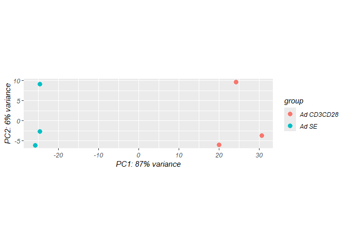

```r
plotPCA(rld, intgroup="condition")
```

## Extraer la matriz de datos transformados con rlog desde el objeto rld

```r
rld_mat <- assay(rld)
```

- Una vez extraída la matriz rld_mat, puedes utilizarla para:
- Análisis exploratorio: Como la realización de análisis de componentes principales (PCA) o clustering jerárquico para visualizar y explorar las relaciones entre las muestras.
- Visualización: Creación de mapas de calor (heatmaps) para observar la expresión génica entre las muestras.

## Calcular la matriz de correlación entre las muestras

Método de correlación: El coeficiente de Pearson mide la relación lineal entre variables.

```r
rld_cor <- cor(rld_mat)
```

## Plot heatmap

- **pheatmap()** toma como entrada una matriz numérica (por ejemplo, una matriz de expresión génica) y genera un mapa de calor donde:
- Filas: representan las observaciones (por ejemplo, genes).
- Columnas: representan las variables (por ejemplo, muestras).
- Colores: indican la magnitud de los valores en la matriz, facilitando la identificación de patrones y relaciones.

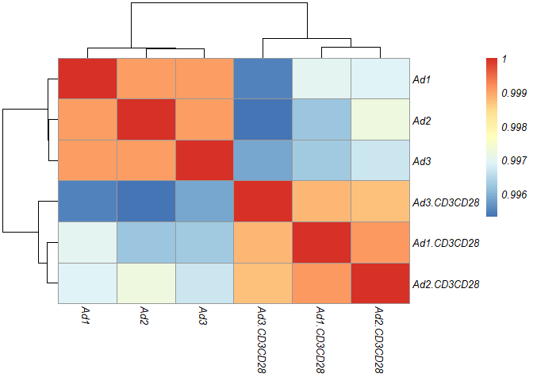

```r
pheatmap(rld_cor)
```

```r
heat.colors <- brewer.pal(6, "Blues")
```

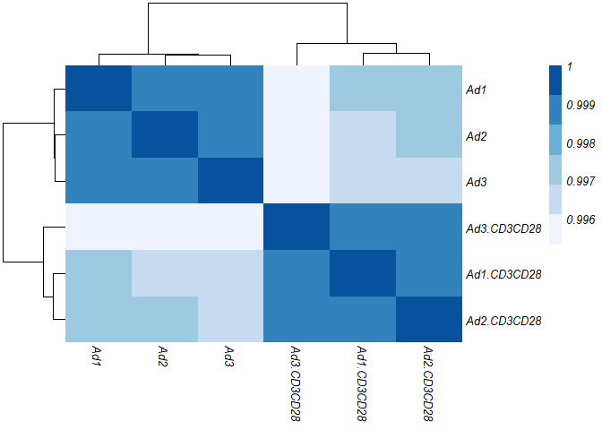

```r
pheatmap(rld_cor, color = heat.colors, border_color=NA, fontsize = 10, fontsize_row = 10, height=20)
```

## Generar gráfico de dispersión de estimaciones

dds_results <- DESeq(dds): Esta línea ejecuta el análisis de expresión génica diferencial utilizando el objeto dds, que contiene los datos de recuento de las muestras. La función DESeq() realiza varios pasos, incluyendo la normalización de los datos, la estimación de dispersión y el ajuste del modelo.

```r
dds_results <- DESeq(dds)
```

```
##   Note: levels of factors in the design contain characters other than
##   letters, numbers, '_' and '.'. It is recommended (but not required) to use
##   only letters, numbers, and delimiters '_' or '.', as these are safe characters
##   for column names in R. [This is a message, not a warning or an error]
```

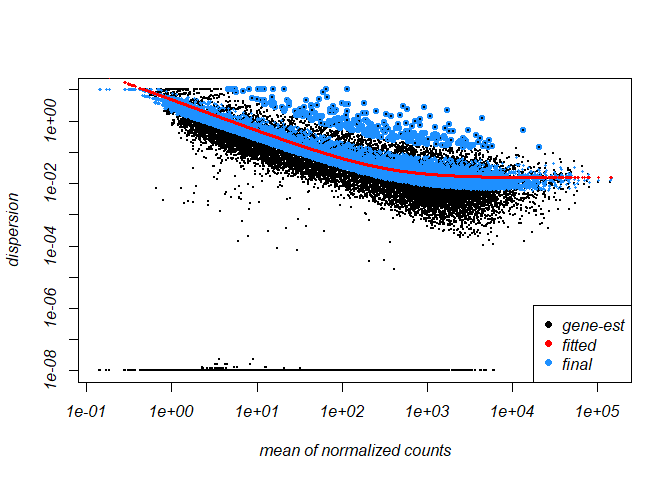

```r
plotDispEsts(dds_results)
```

**¿Qué muestra el gráfico de dispersión?**

El gráfico generado por plotDispEsts() presenta:

Puntos negros: Estimaciones de dispersión por gen.

Línea roja: Ajuste de la relación media-dispersión.

Puntos azules: Estimaciones finales de dispersión utilizadas para las pruebas estadísticas.

Este gráfico es útil para evaluar si los datos se ajustan bien al modelo de DESeq2. Se espera que la dispersión disminuya a medida que aumenta la media de los recuentos. Si observas patrones inusuales o dispersión elevada en genes con baja expresión, podría indicar problemas en los datos o la necesidad de ajustar el modelo.

## Generar contraste y aplicar reducción de LFC

```r
## Definir el contraste entre condiciones

contrast <- c("condition","Ad SE","Ad CD3CD28")

## Obtener resultados sin reducción de LFC

res1 <- results(dds_results,contrast = c("condition","Ad SE","Ad CD3CD28"), alpha = 0.05)


## Aplicar reducción de LFC para mejorar la estimación

res1 <- lfcShrink(dds_results, contrast = c("condition","Ad SE","Ad CD3CD28"), res=res1, type = "normal")
```

```
## using 'normal' for LFC shrinkage, the Normal prior from Love et al (2014).
##
## Note that type='apeglm' and type='ashr' have shown to have less bias than type='normal'.
## See ?lfcShrink for more details on shrinkage type, and the DESeq2 vignette.
## Reference: https://doi.org/10.1093/bioinformatics/bty895
```

```r
## Resumen de los resultados
summary(res1)
```

```
##
## out of 32558 with nonzero total read count
## adjusted p-value < 0.05
## LFC > 0 (up)       : 1992, 6.1%
## LFC < 0 (down)     : 3126, 9.6%
## outliers [1]       : 15, 0.046%
## low counts [2]     : 13155, 40%
## (mean count < 4)
## [1] see 'cooksCutoff' argument of ?results
## [2] see 'independentFiltering' argument of ?results
```

## Generar gráfico MA para visualizar genes diferencialmente expresados

Este código genera un gráfico MA (log-ratio vs. abundance), que es útil para visualizar resultados de análisis de expresión génica diferencial, típicamente en experimentos de RNA-Seq. Este tipo de gráfico te ayuda a identificar genes que están significativamente sobreexpresados o subexpresados entre dos condiciones.

**plotMA(…):** Esta función es de la librería DESeq2 en R. Se usa para crear un gráfico donde:

- El eje x representa la media de la expresión normalizada de cada gen (abundancia).
- El eje y representa el log2 fold change (cambio relativo en expresión entre dos condiciones).

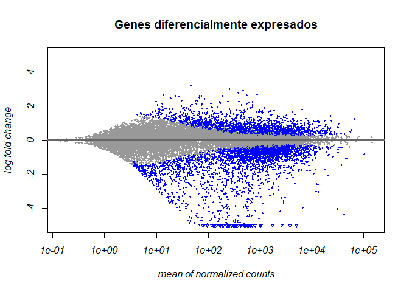

```r
plotMA(res1, ylim=c(-5,5), main="Genes diferencialmente expresados")
```

## Crear un dataframe

```r
res <- data.frame(res1)
padj.cutoff <- 0.05
lfc.cutoff <- 1
```

## Filtrar y guardar genes diferencialmente expresados con LFC ≥ 1

```r
## Convertir los resultados a un tibble y agregar nombres de genes

res_table1 <- res %>% data.frame()%>%rownames_to_column(var="gene") %>% as_tibble()

## Filtrar genes con valor ajustado de p (padj) menor o igual al umbral

sig1_padj<-res %>% filter(padj <=padj.cutoff)

## Filtrar genes con padj < 0.05 y LFC absoluto > 1

sig1 <- res_table1 %>% filter((padj < padj.cutoff) & (abs(log2FoldChange) > lfc.cutoff)) %>% arrange(desc(log2FoldChange))

## Filtrar genes con padj < 0.05 y LFC positivo > 1

sigSE <- res_table1 %>% filter(padj < padj.cutoff & log2FoldChange > lfc.cutoff)

## Filtrar genes con padj < 0.05 y LFC negativo < -1

sigCD3CD28<- res_table1 %>% filter(padj < padj.cutoff & log2FoldChange < -lfc.cutoff)


## Mostrar dimensiones de los subconjuntos

dim(sigSE)
```

```
## [1] 522   7
```

```r
dim(sigCD3CD28)
```

```
## [1] 1433    7
```

```r
dim(sig1)
```

```
## [1] 1955    7
```

```r
## Mostrar las primeras 100 filas de sigCD3CD28

head(sigCD3CD28, n=100)
```

```
## # A tibble: 100 × 7
##    gene        baseMean log2FoldChange lfcSE  stat       pvalue        padj
##    <chr>          <dbl>          <dbl> <dbl> <dbl>        <dbl>       <dbl>
##  1 XLOC_000986     8.09          -1.55 0.535 -2.83 0.00469      0.0212
##  2 XLOC_000988     5.97          -1.93 0.553 -3.33 0.000882     0.00504
##  3 XLOC_002947     5.39          -1.57 0.552 -2.73 0.00637      0.0274
##  4 XLOC_003913    34.7           -2.37 0.423 -5.49 0.0000000408 0.000000613
##  5 XLOC_003921     7.41          -2.39 0.553 -4.33 0.0000151    0.000137
##  6 XLOC_004229    13.9           -1.36 0.495 -2.71 0.00664      0.0283
##  7 XLOC_006357     3.72          -1.40 0.545 -2.64 0.00826      0.0342
##  8 XLOC_006358    25.0           -1.68 0.423 -3.92 0.0000884    0.000666
##  9 XLOC_006572     4.82          -1.69 0.550 -3.01 0.00262      0.0128
## 10 XLOC_007590    48.5           -1.58 0.414 -3.79 0.000148     0.00106
## # ℹ 90 more rows
```

```r
## Guardar resultados en archivos de texto

write.table(sigSE,file = here("resultados_tablas/Ad_SE.txt"), sep = "\t", col.names = TRUE)

write.table(sigCD3CD28, file= here("resultados_tablas/Ad_CD3CD28.txt"), sep = "\t", col.names = TRUE)
```

## Análisis de enriquecimiento de conjuntos de genes con ClusterProfiler

[**ClusterProfiler**](https://github.com/YuLab-SMU/clusterProfiler)

## Librerias parte 2

Si ya tienes una lista de genes diferencialmente expresados (DEGs) en formato de símbolos de genes, puedes utilizar la función bitr() del paquete clusterProfiler para convertir estos identificadores a ENTREZID. Asegúrate de tener cargado el paquete org.Hs.eg.db para acceder a la base de datos de anotación de genes humanos

```r
library(clusterProfiler)
library(org.Hs.eg.db)
library(ggplot2)
#packageDescription("clusterProfiler")
```

- Necesitamos los entrezgenid de las variable

```r
# Convertir símbolos de genes a ENTREZID
GDE_SE_ENTREZ <- bitr(sigSE$gene, fromType = "SYMBOL", toType = "ENTREZID", OrgDb = org.Hs.eg.db)
GDE_ES_ENTREZ <- bitr(sigCD3CD28$gene, fromType = "SYMBOL", toType = "ENTREZID", OrgDb = org.Hs.eg.db)
head(GDE_SE_ENTREZ)
```

```
##     SYMBOL ENTREZID
## 72  TAS1R3    83756
## 73   MXRA8    54587
## 74   MEGF6     1953
## 75   AJAP1    55966
## 78 LDLRAP1    26119
## 79  CRYBG2    55057
```

```r
head(GDE_ES_ENTREZ)
```

```
##      SYMBOL ENTREZID
## 45 TNFRSF18     8784
## 46  TNFRSF4     7293
## 47   ATAD3A    55210
## 48 TNFRSF14     8764
## 49     TP73     7161
## 50   RNF207   388591
```

```r
SE <-sigSE$gene
ES <-sigCD3CD28$gene
GDE_SE = bitr(SE, fromType="SYMBOL", toType="ENTREZID", OrgDb="org.Hs.eg.db")
head(GDE_SE)
```

```
##     SYMBOL ENTREZID
## 72  TAS1R3    83756
## 73   MXRA8    54587
## 74   MEGF6     1953
## 75   AJAP1    55966
## 78 LDLRAP1    26119
## 79  CRYBG2    55057
```

```r
GDE_ES = bitr(ES, fromType="SYMBOL", toType="ENTREZID", OrgDb="org.Hs.eg.db")
head(GDE_ES)
```

```
##      SYMBOL ENTREZID
## 45 TNFRSF18     8784
## 46  TNFRSF4     7293
## 47   ATAD3A    55210
## 48 TNFRSF14     8764
## 49     TP73     7161
## 50   RNF207   388591
```

```r
GDE_SE_ENTREZ <-GDE_SE$ENTREZID
GDE_ES_ENTREZ <-GDE_ES$ENTREZID
```

# Análisis de enriquecimiento funcional comparativo con compareCluster

- El paquete clusterProfiler en R ofrece la función compareCluster() para comparar perfiles funcionales de diferentes conjuntos de genes. Esta herramienta es útil para identificar diferencias y similitudes en las funciones biológicas entre distintos grupos de genes, como los genes diferencialmente expresados en diferentes condiciones experimentales.

```r
## Comparar perfiles funcionales de conjuntos de genes mediante análisis de enriquecimiento GO
mi_lista <- list("SE_ADULTOS" = GDE_SE_ENTREZ, "ES_Adultos" = GDE_ES_ENTREZ)

## Realizar el análisis de enriquecimiento GO para cada conjunto de genes
ck1 <- compareCluster(geneCluster = mi_lista, fun = "enrichGO", OrgDb = "org.Hs.eg.db", ont = "BP")

## Guardar los resultados en un archivo txt

head(as.data.frame(ck1))  # Mostrar las primeras filas de los resultados
```

```
##      Cluster         ID                               Description GeneRatio
## 1 SE_ADULTOS GO:0061448             connective tissue development    18/293
## 2 ES_Adultos GO:0006260                           DNA replication   79/1136
## 3 ES_Adultos GO:0006261             DNA-templated DNA replication   60/1136
## 4 ES_Adultos GO:0007059                    chromosome segregation   97/1136
## 5 ES_Adultos GO:0000280                          nuclear division   93/1136
## 6 ES_Adultos GO:1901987 regulation of cell cycle phase transition   94/1136
##     BgRatio       pvalue     p.adjust       qvalue
## 1 285/18870 5.491646e-07 1.877594e-03 1.706457e-03
## 2 278/18870 1.895580e-32 9.868245e-29 7.689187e-29
## 3 161/18870 3.709867e-32 9.868245e-29 7.689187e-29
## 4 424/18870 3.360736e-31 5.959706e-28 4.643712e-28
## 5 441/18870 4.315619e-27 5.739773e-24 4.472344e-24
## 6 456/18870 1.368659e-26 1.456254e-23 1.134691e-23
##                                                                                                                                                                                                                                                                                                          …
## 1                                                                                                                                                                                                                                                                                                        …
## 2                                                                                                                             378708/4678/4998/51514/6241/348654/4175/580/10293/10721/4171…
## 3                                                                                                                                                                                                                                     378708/4998/348654/4175/580/10293/10721/4171/5984/604/51053/…
## 4 378708/55143/991/11004/6491/84722/83540/259266/9928/4751/106…
## 5                                        378708/2827/55143/991/11004/8438/84722/83540/259266/9928/475…
## 6                                                            26270/63967/55143/991/6491/1031/4998/4582/83540/9928/8444/25…
##   Count
## 1    18
## 2    79
## 3    60
## 4    97
## 5    93
## 6    94
```

```r
x <- as.data.frame(ck1)
write.table(x, file = here("resultados_tablas/listas_enrichGO_PE.txt"), sep = "\t", col.names = TRUE)
head(ck1)  # Ver los resultados en una ventana interactiva
```

```
##      Cluster         ID                               Description GeneRatio
## 1 SE_ADULTOS GO:0061448             connective tissue development    18/293
## 2 ES_Adultos GO:0006260                           DNA replication   79/1136
## 3 ES_Adultos GO:0006261             DNA-templated DNA replication   60/1136
## 4 ES_Adultos GO:0007059                    chromosome segregation   97/1136
## 5 ES_Adultos GO:0000280                          nuclear division   93/1136
## 6 ES_Adultos GO:1901987 regulation of cell cycle phase transition   94/1136
##     BgRatio       pvalue     p.adjust       qvalue
## 1 285/18870 5.491646e-07 1.877594e-03 1.706457e-03
## 2 278/18870 1.895580e-32 9.868245e-29 7.689187e-29
## 3 161/18870 3.709867e-32 9.868245e-29 7.689187e-29
## 4 424/18870 3.360736e-31 5.959706e-28 4.643712e-28
## 5 441/18870 4.315619e-27 5.739773e-24 4.472344e-24
## 6 456/18870 1.368659e-26 1.456254e-23 1.134691e-23
##                                                                                                                                                                                                                                                                                                          …
## 1                                                                                                                                                                                                                                                                                                        …
## 2                                                                                                                             378708/4678/4998/51514/6241/348654/4175/580/10293/10721/4171…
## 3                                                                                                                                                                                                                                     378708/4998/348654/4175/580/10293/10721/4171/5984/604/51053/…
## 4 378708/55143/991/11004/6491/84722/83540/259266/9928/4751/106…
## 5                                        378708/2827/55143/991/11004/8438/84722/83540/259266/9928/475…
## 6                                                            26270/63967/55143/991/6491/1031/4998/4582/83540/9928/8444/25…
##   Count
## 1    18
## 2    79
## 3    60
## 4    97
## 5    93
## 6    94
```

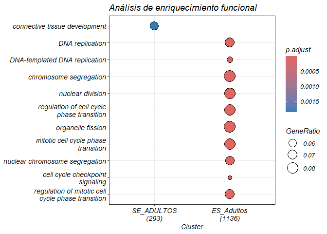

```r
## Visualizar los resultados mediante un gráfico de puntos

dotplot(ck1, showCategory = 10, font.size = 10.5) + ggtitle("Análisis de enriquecimiento funcional")
```

## Volcano plot

[**EnhancedVolcano**](https://bioconductor.org/packages/devel/bioc/vignettes/EnhancedVolcano/inst/doc/EnhancedVolcano.html)

- Un volcano plot es una herramienta visual utilizada en análisis de expresión diferencial para representar la relación entre la magnitud del cambio (fold change) y la significancia estadística (valor p) de cada gen. En este gráfico:
- El eje x muestra el log₂ del fold change (log₂FC), indicando la magnitud del cambio en la expresión génica entre dos condiciones.
- El eje y muestra el valor p ajustado o el valor p negativo logaritmado (-log₁₀(p)), representando la significancia estadística del cambio observado.
- Los puntos en las esquinas superiores del gráfico suelen representar genes que son tanto estadísticamente significativos como biológicamente relevantes, es decir, aquellos con un gran cambio en la expresión y un valor p bajo.

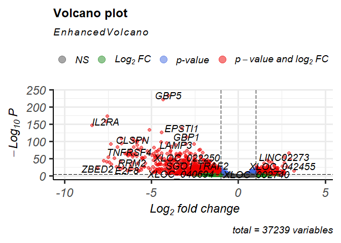

```r
library(EnhancedVolcano)

# Generar el volcano plot

EnhancedVolcano(res1,
    lab = rownames(res1),
    x = 'log2FoldChange',
    y = 'pvalue')
```

## Referencias

[Deseq2](https://bioconductor.org/packages/devel/bioc/vignettes/DESeq2/inst/doc/DESeq2.html)